# Employee Compensation Plan

Sanika Karwa

2022-12-01

# Employee Compensation Plan Dataset

For the final project for ISE 201, I have selected a dataset Employee Compensation for the year 2021 listed on San Jose Data(https://data.sanjoseca.gov/dataset/employee-compensation-plan).

```r
# Importing the required libraries
library(tidyverse)
```

```r
library(ggplot2)
library(dplyr)
library(tidyr)

# Reading the dataset
myData <- read.csv("employee-compensation-2021.csv")
head(myData,3)
```

```
##                  Name Department Job.Title..as.of.12.31.21.
## 1    Galvin Charekian       Fire               Fire Captain
## 2 Christian Camarillo     Police            Police Sergeant
## 3       Gustavo Perez     Police          Police Lieutenant
##   Total.Cash.Compensation   Base.Pay   Overtime Sick.and.Vacation.Payouts
## 1              444,285.82 165,070.36 265,251.46
## 2              388,823.00 156,696.80 201,212.59
## 3              381,737.39 181,486.40 158,793.62
##   Other.Cash.Compensation Defined.Contribution.Plan.Contributions...City.Paid
## 1               13,964.00
## 2               30,913.61
## 3               41,457.37
##   Medical.Dental.Vision Retirement.Contributions..Normal.Cost....City.Paid
## 1             20,874.60                                          54,863.62
## 2             20,874.60                                          54,501.23
## 3             20,874.60                                          63,123.33
##   Long.Term.Disability..Life..Medicare Misc.Employment.Related.Costs
## 1                             6,434.72                      1,144.21
## 2                             5,604.32                        938.07
## 3                             5,510.28                           950
```

```r
# Dimensions of the dataset
dim(myData)
```

```
## [1] 8162   13
```

The dataset contains 8162 rows(observations) and 13 columns(variables).

```r
# Discarding the "Name" column
myData <- myData %>% select(-Name)
```

Here, we remove the “Name” column as we want to discard the columns with personal information.

```r
# Renaming the columns
myData <- myData %>% rename("job_title_as_of_12_31_21" = "Job.Title..as.of.12.31.21.",
                           "total_cash_compensation" = "Total.Cash.Compensation",
                           "base_pay" = "Base.Pay" ,
                           "overtime" = "Overtime",
                           "sick_and_vacation_payouts" = "Sick.and.Vacation.Payouts",
                           "other_cash_compensation" = "Other.Cash.Compensation",
                           "defined_contribution_plan_contributions" = "Defined.Contribution.Plan.Contributions...City.Paid",
                           "medical_dental_vision" = "Medical.Dental.Vision" ,
                           "long_term_disability_life_medicare" = "Long.Term.Disability..Life..Medicare",
                           "retirement_contributions_normal_cost" = "Retirement.Contributions..Normal.Cost....City.Paid",
                           "misc_employment_related_costs" = "Misc.Employment.Related.Costs" )
```

Renaming the columns of the dataset as they have spaces between them and they are identified as fullstops so to make them understandable, renaming them with underscores in the middle.

# Introduction

### What are you curious to know about from the data you have selected? A sentence or two explaining why are you interested in studying this?

How the Department affects the total cash compensation that an employee will get? Does the base pay and overtime have any relation with total cash compensation? Which department gets how much sick and vacation payouts?

The above questions are the ones that I am curious to know from the dataset.  
This dataset is useful to understand the trends on how an employee gets the compensation for their particular department and job title. These are valid and necessary questions for the employee and his wellbeing.

# About the Data

### Data source - citation or link to the source

San Jose Data: https://data.sanjoseca.gov/dataset/employee-compensation-plan/resource/205afc93-b3d2-4199-8d44-14a435b84dd7?inner_span=True

### Data collection: How and when was data collected? Is it observational study or from an experiment?

This data was collected by the Government. This is for every individual and there are 8162 employees’ data in it. It is an observational study.

### Units of observations: What is the unit of observation, in most cases it would mean what each row indicates?

Each row in the dataset represents the compensation given to each employee.

### Variables: What are the variables that you are planning to study ? All or a subset of variables?

The dataset consists of 13 variables but I will be mostly studying the following variables:  
Department  
Total.Cash.Compensation  
Base.Pay  
Overtime  
Other.Cash.Compensation  
Medical.Dental.Vision  
Retirement.Contributions..Normal.Cost….City.Paid  
Long.Term.Disability..Life..Medicare  
Misc.Employment.Related.Costs

```r
# Converting the needed columns into numeric
myData$Department <- as.factor(gsub(",", "", myData$Department))
myData$job_title_as_of_12_31_21 <- as.factor(gsub(",", "", myData$job_title_as_of_12_31_21))
myData$total_cash_compensation <- as.numeric(gsub(",", "", myData$total_cash_compensation))
myData$base_pay <- as.numeric(gsub(",", "", myData$base_pay))
myData$overtime <- as.numeric(gsub(",", "", myData$overtime))
myData$sick_and_vacation_payouts <- as.numeric(gsub(",", "", myData$sick_and_vacation_payouts))
myData$other_cash_compensation <- as.numeric(gsub(",", "", myData$other_cash_compensation))
myData$defined_contribution_plan_contributions <- as.numeric(gsub(",", "", myData$defined_contribution_plan_contributions))
myData$medical_dental_vision <- as.numeric(gsub(",", "", myData$medical_dental_vision))
myData$long_term_disability_life_medicare <- as.numeric(gsub(",", "", myData$long_term_disability_life_medicare))
myData$retirement_contributions_normal_cost <- as.numeric(gsub(",", "", myData$retirement_contributions_normal_cost))
myData$misc_employment_related_costs <- as.numeric(gsub(",", "", myData$misc_employment_related_costs))
```

The dataset originally had all the numeric columns also considered as character columns. As we cannot perform any operations on character columns we convert the required columns in numeric form. The two columns Department and Job title are converted in factor form as they are categorical data. The code for the same is given above where we convert 10 columns in numeric form and 2 columns in factor form.

```r
# Finding the different categories in "Department" column
categories <- unique(myData$Department)
numberOfCategories <- length(categories)
categories
```

```
##  [1] Fire                           Police
##  [3] City Manager                   Retirement Services
##  [5] Attorney                       Environmental Services
##  [7] Library                        Airport
##  [9] Public Works                   Housing
## [11] Finance                        Office Of Economic Development
## [13] Parks/Rec & Neigh Serv P R N S Community Energy Department
## [15] Transportation                 Information Technology
## [17] Independent Police Auditor     Planning/Building/Code
## [19] Human Resources                City Council
## [21] Auditor                        Clerk
## 22 Levels: Airport Attorney Auditor City Council City Manager ... Transportation
```

```r
numberOfCategories
```

```
## [1] 22
```

There are 22 unique categories in the Department column.

```r
# Top 10 department categories in descending order
top10 <- myData %>% count(Department) %>% top_n(10, n) %>% arrange(desc(n))
top10
```

```
##                        Department    n
## 1                          Police 2044
## 2  Parks/Rec & Neigh Serv P R N S 1346
## 3                            Fire  855
## 4                    Public Works  685
## 5                         Library  586
## 6          Environmental Services  525
## 7                  Transportation  525
## 8          Planning/Building/Code  280
## 9                         Airport  218
## 10                Human Resources  190
```

If we go column “Department” wise then there are 2044 Police Department samples which is the max followed by 1346 Parks/Rec & Neigh Serv samples.  
The top 10 categories from Department wise is given here.

### Data cleanup : If you had to do any data clean up please include code and brief description of steps, e.g. handling missing observations, transforming variables, filtering on rows, removing outliers.

Our dataset does not contain invalid values.

```r
# Checking for duplicated values
sum(duplicated(myData))
```

```
## [1] 41
```

There are 41 duplicated values in the dataset.

```r
# Cleaning the duplicated values in the dataset
myData <- myData %>% distinct()
sum(duplicated(myData))
```

```
## [1] 0
```

We remove these duplicated values using the distinct() function.

```r
# Checking for missing values
sum(is.na(myData))
```

```
## [1] 22034
```

There are a lot of missing values in the dataset. To handle these cases we will impute the values/remove them depending on number of missing values,

```r
# Checking for missing values in each column
colSums(is.na(myData))
```

```
##                              Department                job_title_as_of_12_31_21
##                                       0                                       0
##                 total_cash_compensation                                base_pay
##                                       0                                      53
##                                overtime               sick_and_vacation_payouts
##                                    3677                                    7141
##                 other_cash_compensation defined_contribution_plan_contributions
##                                    1182                                    5876
##                   medical_dental_vision    retirement_contributions_normal_cost
##                                    1882                                    2189
##      long_term_disability_life_medicare           misc_employment_related_costs
##                                      12                                      22
```

The max number of missing data is in the “Sick.and.Vacation.Payouts” columns followed by “Defined.Contribution.Plan.Contributions…City.Paid” column. In our case, we will ignore these columns for further computations. These columns in comparison to the other columns are not of much importance and when looked at the dataset, it can be ignored.

```r
# What percent of data is missing from each variable
p <- function(x) {sum(is.na(x))/length(x)*100}
apply(myData, 2, p)
```

```
##                              Department                job_title_as_of_12_31_21
##                               0.0000000                               0.0000000
##                 total_cash_compensation                                base_pay
##                               0.0000000                               0.6526290
##                                overtime               sick_and_vacation_payouts
##                              45.2776752                              87.9325206
##                 other_cash_compensation defined_contribution_plan_contributions
##                              14.5548578                              72.3556212
##                   medical_dental_vision    retirement_contributions_normal_cost
##                              23.1744859                              26.9548085
##      long_term_disability_life_medicare           misc_employment_related_costs
##                               0.1477651                               0.2709026
```

Here, we find out the percent of missing values over the complete dataset for each column. This is done to see which values we will impute and for which ones we can remove the rows.

```r
# Replacing with 0 & 1 in a new column for sick and vacation payouts
myData$sick_and_vacation_availed <- ifelse(is.na(myData$sick_and_vacation_payouts), 0, 1)
head(myData,3)
```

```
##   Department job_title_as_of_12_31_21 total_cash_compensation base_pay overtime
## 1       Fire             Fire Captain                444285.8 165070.4 265251.5
## 2     Police          Police Sergeant                388823.0 156696.8 201212.6
## 3     Police        Police Lieutenant                381737.4 181486.4 158793.6
##   sick_and_vacation_payouts other_cash_compensation
## 1                        NA                13964.00
## 2                        NA                30913.61
## 3                        NA                41457.37
##   defined_contribution_plan_contributions medical_dental_vision
## 1                                      NA               20874.6
## 2                                      NA               20874.6
## 3                                      NA               20874.6
##   retirement_contributions_normal_cost long_term_disability_life_medicare
## 1                             54863.62                            6434.72
## 2                             54501.23                            5604.32
## 3                             63123.33                            5510.28
##   misc_employment_related_costs sick_and_vacation_availed
## 1                       1144.21                         0
## 2                        938.07                         0
## 3                        950.00                         0
```

Here, we make a new column called “sick_and_vacation_availed” in place of “sick_and_vacation_payouts” wherein, if the value is NA we replace it with 0 and if there is a value in the column we will replace it with 1. This is converting continuous variable to categorical variable.

```r
# Handling missing values
cleanData <- myData %>% select(Department, job_title_as_of_12_31_21, total_cash_compensation, base_pay, overtime, sick_and_vacation_availed, other_cash_compensation, medical_dental_vision, retirement_contributions_normal_cost, long_term_disability_life_medicare, misc_employment_related_costs )

cleanData <- cleanData %>% drop_na(long_term_disability_life_medicare)
cleanData <- cleanData %>% drop_na(misc_employment_related_costs)
cleanData <- cleanData %>% drop_na(base_pay)

cleanData[is.na(cleanData)] <- 0
head(cleanData)
```

```
##     Department job_title_as_of_12_31_21 total_cash_compensation base_pay
## 1         Fire             Fire Captain                444285.8 165070.4
## 2       Police          Police Sergeant                388823.0 156696.8
## 3       Police        Police Lieutenant                381737.4 181486.4
## 4       Police Deputy Chief of Police U                375185.4 229947.0
## 5 City Manager           City Manager U                374001.5 210675.8
## 6 City Manager           City Manager U                373443.3 349363.1
##   overtime sick_and_vacation_availed other_cash_compensation
## 1 265251.5                         0                13964.00
## 2 201212.6                         0                30913.61
## 3 158793.6                         0                41457.37
## 4 111468.6                         0                33769.89
## 5      0.0                         1                12974.93
## 6      0.0                         0                24080.23
##   medical_dental_vision retirement_contributions_normal_cost
## 1              20874.60                             54863.62
## 2              20874.60                             54501.23
## 3              20874.60                             63123.33
## 4              22400.19                             77259.50
## 5               9043.23                             38707.36
## 6               2086.20                             64694.81
##   long_term_disability_life_medicare misc_employment_related_costs
## 1                            6434.72                       1144.21
## 2                            5604.32                        938.07
## 3                            5510.28                        950.00
## 4                            5784.00                        854.78
## 5                            6232.80                       1002.20
## 6                            6770.30                       1057.97
```

Here, we handle the missing values in the dataset and it is stored in a new dataframe called cleanData.

First, we select the columns that we need and are going to use. We discarded columns with most number of missing values. In our case, we discarded 2 columns namely, “sick_and_vacation_payouts” and “defined_contribution_plan_contributions”. But, we keep the “sick_and_vacation_availed” column.

Second, we remove the rows whose column has less number of missing values. In our case, we did this for 3 columns namely, “long_term_disability_life_medicare”, “misc_employment_related_costs” and “base_pay”. The missing values in these columns are less than 1% of the total dataset.

Third, we replace the NA values with 0 in the remaining cases as this wont affect the visualizations. This is done for data less than 50% of the missing values. I initially tried replacing with the mean but it did not give me accurate results and hence, I replaced these values with 0 so it does not affect my visualizations.

```r
# using subset function
newdata <- subset(cleanData, cleanData$Department == "Police" | cleanData$Department == "Parks/Rec & Neigh Serv P R N S" | cleanData$Department == "Fire" | cleanData$Department == "Public Works" | cleanData$Department == "Library", select=Department:overtime)
```

In the above we just subset our data based on top 5 departments in order of their frequency for few columns.

#### Data cleanup is now done. We will work on this clean data further for Exploratory Data Analysis.

# Exploratory Data Analysis

The following are the relevant visualisations of the data and the summary statistics of the same.

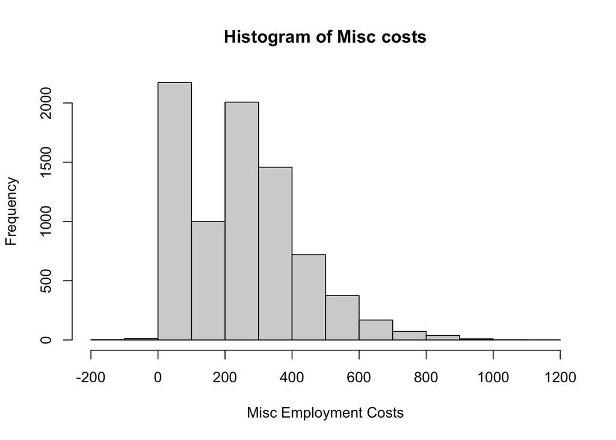

```r
# Histogram plotting
hist(cleanData$misc_employment_related_costs, xlab='Misc Employment Costs', main='Histogram of Misc costs')
```

In this histogram, we can see the frequency of Misc Employment Related Costs. We see that maximum number of people receive Miscellaneous Costs under $100 which is surprising and something we would not expect. After that, maximum number of people receive in the range of $200 - $400 and it is slightly right skewed.

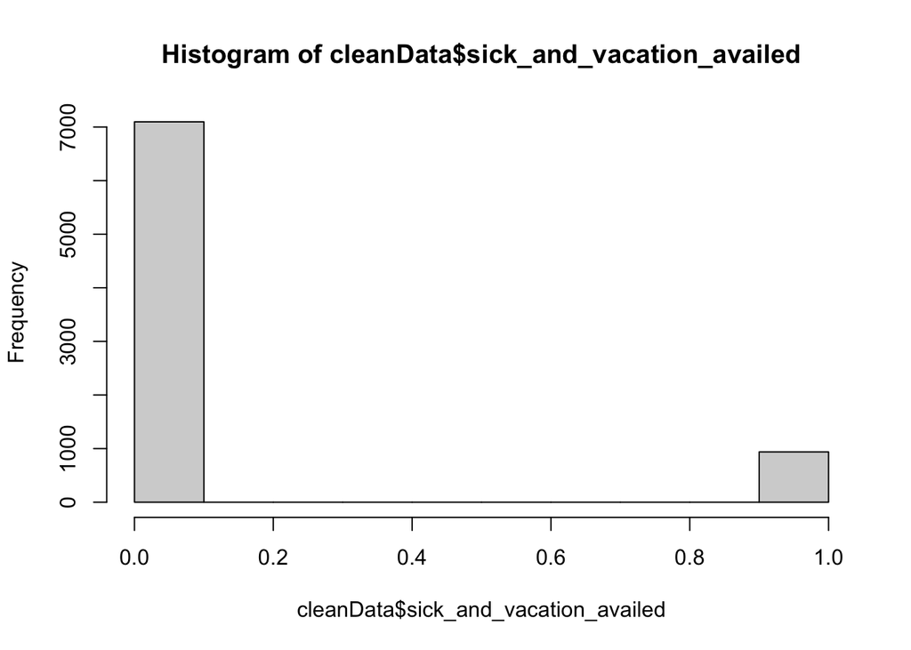

```r
# Histogram plotting
hist(cleanData$sick_and_vacation_availed)
```

The above is a simple plot which shows that not a lot of people get paid for sick_and_vacation and hence frequency of 0’s is more than 1’s.

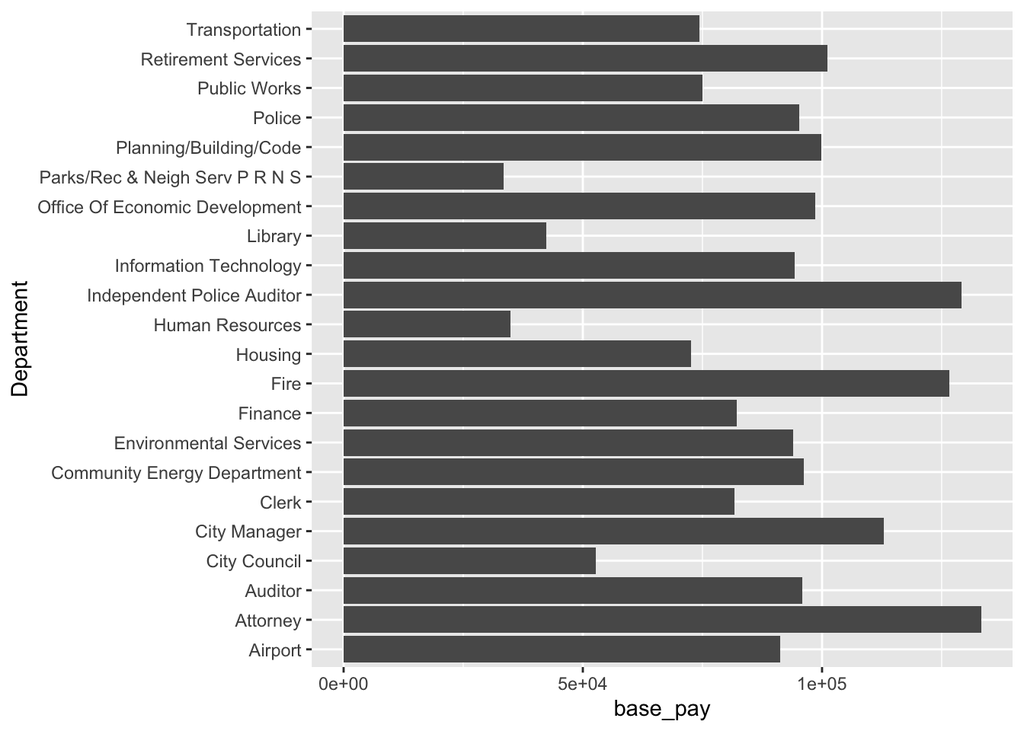

```r
ggplot(cleanData,aes(Department,base_pay)) +
  geom_bar(position = "dodge",
           stat = "summary",
           fun = "mean") +
  coord_flip()
```

In the above plot we see that the base_pay of Attorney is highest followed by Independent Police Auditor. The least is of Parks/Rec & Neigh Serv PRNS.

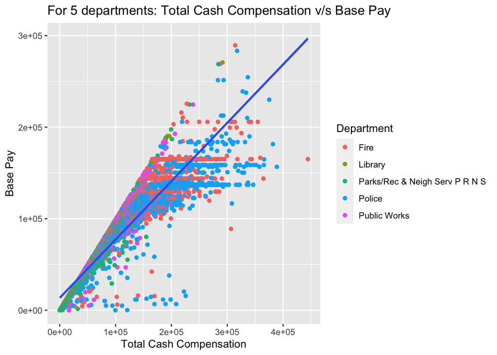

```r
# Plotting a scatter plot for 5 departments
ggplot(data = newdata, aes(x = total_cash_compensation,y = base_pay)) +
  geom_point(aes(color = Department)) + geom_smooth(method = "lm") +  xlab("Total Cash Compensation") + ylab("Base Pay") + labs(colour="Department") +
  ggtitle("For 5 departments: Total Cash Compensation v/s Base Pay")
```

```r
# Correlation value
cor(newdata$total_cash_compensation,newdata$base_pay)
```

```
## [1] 0.9380499
```

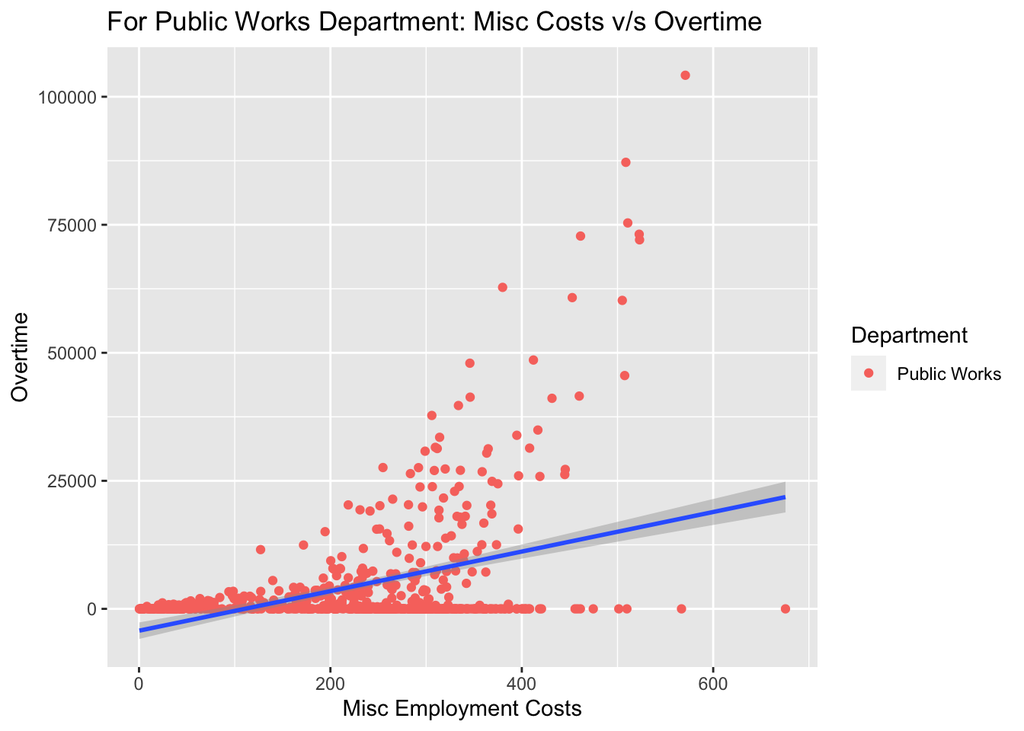

```r
# Subsetting a part of data
publicworksData <- subset(cleanData, cleanData$Department == "Public Works", select=Department:misc_employment_related_costs)

# Plotting a scatter plot for the Public Works department
ggplot(data = publicworksData, aes(x = misc_employment_related_costs , y = overtime)) +
  geom_point(aes(color = Department))+ geom_smooth(method = "glm") + xlab("Misc Employment Costs") + ylab("Overtime")  + ggtitle("For Public Works Department: Misc Costs v/s Overtime")
```

```r
# Correlation value
cor(publicworksData$misc_employment_related_costs, publicworksData$overtime)
```

```
## [1] 0.4138181
```

```r
# subsetting only the police department and getting those values
policedept <- subset(myData, Department == "Police")

# Grouping of the police department by Job title and total cash compensation
police_df <- policedept %>% group_by(job_title_as_of_12_31_21) %>%
  select(job_title_as_of_12_31_21, overtime) %>%
  arrange(desc(overtime))
head(police_df,3)
```

```
## # A tibble: 3 × 2
## # Groups:   job_title_as_of_12_31_21 [2]
##   job_title_as_of_12_31_21 overtime
##   <fct>                       <dbl>
## 1 Police Sergeant           201213.
## 2 Police Officer            180480.
## 3 Police Sergeant           179085.
```

Here, we group the Police Department by their individual Job Title associated with their respective overtime values and arranged it in the descending order.

```r
# Sampling only the top 50 rows to visualize better
samplepolice <- sample_n(policedept, 50)
head(samplepolice, 3)
```

```
##   Department job_title_as_of_12_31_21 total_cash_compensation base_pay overtime
## 1     Police        Police Lieutenant                99665.65      0.0 23924.23
## 2     Police          Police Sergeant               169406.97  58464.0  4976.96
## 3     Police           Police Officer               178797.37 137062.4 17356.05
##   sick_and_vacation_payouts other_cash_compensation
## 1                  75741.42                    0.00
## 2                  95332.45                10633.56
## 3                        NA                24378.92
##   defined_contribution_plan_contributions medical_dental_vision
## 1                                      NA                    NA
## 2                                      NA                 170.5
## 3                                      NA               20874.6
##   retirement_contributions_normal_cost long_term_disability_life_medicare
## 1                                   NA                            1445.15
## 2                             20695.55                            1919.05
## 3                             47674.46                            2582.30
##   misc_employment_related_costs sick_and_vacation_availed
## 1                        221.00                         1
## 2                        351.08                         1
## 3                        363.87                         0
```

Here, we sampled the dataset with 50 values and stored it in samplepolice variable.

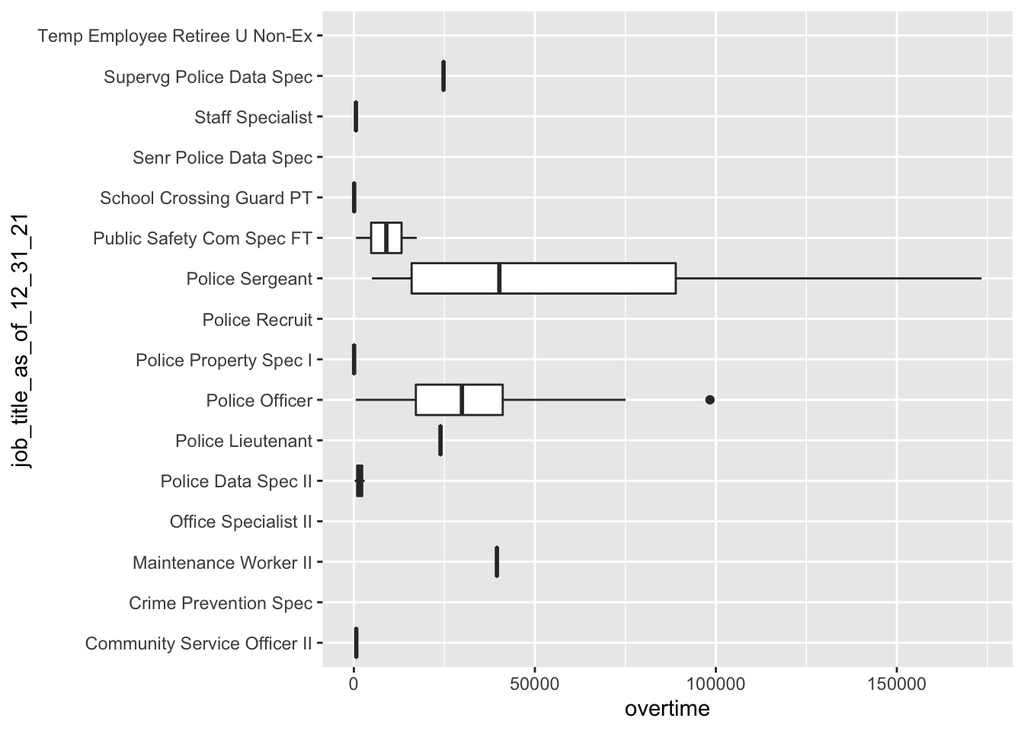

```r
# Box plot of job title v/s overtime
ggplot(samplepolice) +
  geom_boxplot(mapping = aes(x = job_title_as_of_12_31_21, y = overtime)) +
  coord_flip()
```

```r
# subsetting only the fire department and getting those values
firedept <- subset(myData, Department == "Fire")

# Grouping of the fire department by Job title and total cash compensation
fire_df <- firedept %>% group_by(job_title_as_of_12_31_21) %>%
  select(job_title_as_of_12_31_21, total_cash_compensation) %>%
  arrange(desc(total_cash_compensation))
head(fire_df,3)
```

```
## # A tibble: 3 × 2
## # Groups:   job_title_as_of_12_31_21 [2]
##   job_title_as_of_12_31_21 total_cash_compensation
##   <fct>                                      <dbl>
## 1 Fire Captain                             444286.
## 2 Fire Engineer                            364809.
## 3 Fire Captain                             359119.
```

```r
# Sampling only the top 50 rows to visualize better
samplefire <- sample_n(firedept, 50)
head(samplefire, 3)
```

```
##   Department job_title_as_of_12_31_21 total_cash_compensation base_pay overtime
## 1       Fire  Supervg Pub Safety Disp                158414.0 132138.9 18100.68
## 2       Fire             Fire Captain                213773.5 165070.4 37718.58
## 3       Fire            Fire Engineer                167195.4 143852.3 20897.38
##   sick_and_vacation_payouts other_cash_compensation
## 1                        NA                 8174.40
## 2                        NA                10984.51
## 3                        NA                 2445.70
##   defined_contribution_plan_contributions medical_dental_vision
## 1                                      NA                 601.2
## 2                                      NA                1513.8
## 3                                      NA               20874.6
##   retirement_contributions_normal_cost long_term_disability_life_medicare
## 1                             24465.56                            2358.36
## 2                             54563.25                            3136.47
## 3                             46990.33                            2367.22
##   misc_employment_related_costs sick_and_vacation_availed
## 1                        446.29                         0
## 2                        489.64                         0
## 3                        395.05                         0
```

Here, we sampled the dataset with 50 values and stored it in samplefire variable.

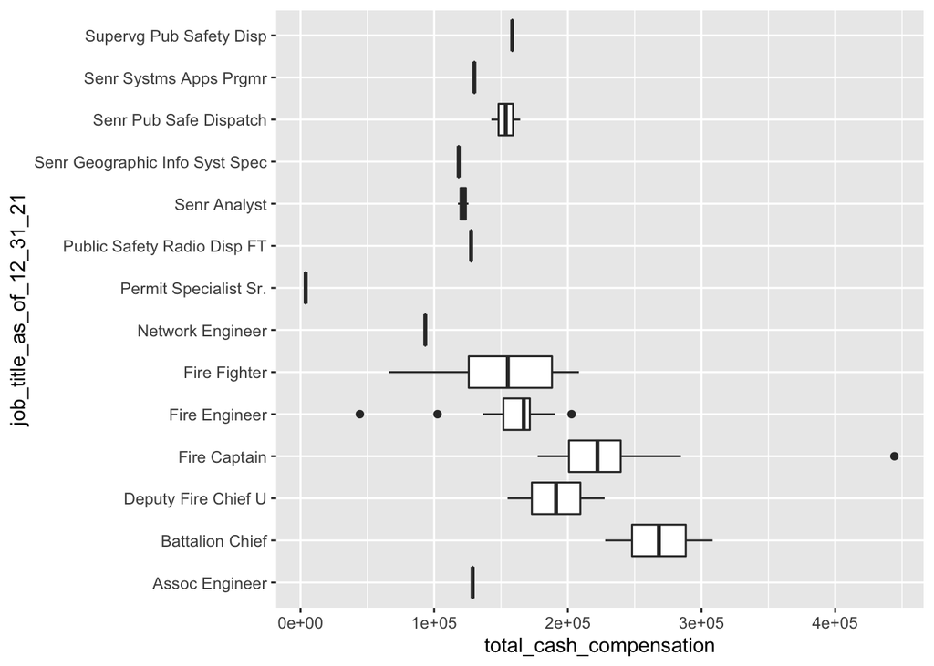

```r
# Box plot of job title v/s base pay
ggplot(samplefire) +
  geom_boxplot(mapping = aes(x = job_title_as_of_12_31_21, y = total_cash_compensation)) +
  coord_flip()
```

```r
# Summary statistics of clean data
summary(cleanData)
```

```
##                           Department               job_title_as_of_12_31_21
##  Police                        :2007   Police Officer          : 919
##  Parks/Rec & Neigh Serv P R N S:1321   Recreation Leader PT    : 678
##  Fire                          : 842   Fire Fighter            : 239
##  Public Works                  : 682   Fire Engineer           : 229
##  Library                       : 576   Library Page PT         : 206
##  Environmental Services        : 522   School Crossing Guard PT: 200
##  (Other)                       :2085   (Other)                 :5564
##  total_cash_compensation    base_pay         overtime
##  Min.   :    12.3        Min.   :     0   Min.   :     0.0
##  1st Qu.: 30473.4        1st Qu.: 27482   1st Qu.:     0.0
##  Median : 88652.2        Median : 81116   Median :   150.4
##  Mean   : 96767.5        Mean   : 79477   Mean   : 10451.8
##  3rd Qu.:141717.9        3rd Qu.:119610   3rd Qu.:  8515.8
##  Max.   :444285.8        Max.   :349363   Max.   :265251.5
##
##  sick_and_vacation_availed other_cash_compensation medical_dental_vision
##  Min.   :0.0000            Min.   :-3269.2         Min.   :    0
##  1st Qu.:0.0000            1st Qu.:  307.6         1st Qu.:  249
##  Median :0.0000            Median : 1752.0         Median : 8193
##  Mean   :0.1167            Mean   : 5586.1         Mean   : 9004
##  3rd Qu.:0.0000            3rd Qu.: 6797.5         3rd Qu.:16751
##  Max.   :1.0000            Max.   :47003.2         Max.   :26513
##
##  retirement_contributions_normal_cost long_term_disability_life_medicare
##  Min.   : -2666                       Min.   :   0.18
##  1st Qu.:     0                       1st Qu.: 432.74
##  Median :  6658                       Median :1314.00
##  Mean   : 13470                       Mean   :1462.90
##  3rd Qu.: 18466                       3rd Qu.:2208.84
##  Max.   :128179                       Max.   :6770.30
##
##  misc_employment_related_costs
##  Min.   :-128.4
##  1st Qu.:  82.4
##  Median : 247.9
##  Mean   : 246.3
##  3rd Qu.: 346.5
##  Max.   :1144.2
##
```

The above show the summary statistics of the cleanData after removing all the missing and duplicate values. We have to avoid the column sick_and_vacation_availed as it has only 0’s and 1’s but by the mean value we can say the value is biased towards 0 and hence it has a lot of 0’s.

# Principal Component Analysis

```r
# Selecting the numeric required columns
pca_data <- cleanData %>% select(total_cash_compensation, base_pay, overtime, sick_and_vacation_availed, other_cash_compensation, medical_dental_vision,retirement_contributions_normal_cost, long_term_disability_life_medicare, misc_employment_related_costs)
head(pca_data,3)
```

```
##   total_cash_compensation base_pay overtime sick_and_vacation_availed
## 1                444285.8 165070.4 265251.5                         0
## 2                388823.0 156696.8 201212.6                         0
## 3                381737.4 181486.4 158793.6                         0
##   other_cash_compensation medical_dental_vision
## 1                13964.00               20874.6
## 2                30913.61               20874.6
## 3                41457.37               20874.6
##   retirement_contributions_normal_cost long_term_disability_life_medicare
## 1                             54863.62                            6434.72
## 2                             54501.23                            5604.32
## 3                             63123.33                            5510.28
##   misc_employment_related_costs
## 1                       1144.21
## 2                        938.07
## 3                        950.00
```

In the above code snippet, we select the numeric columns needed and stored into a new variable.

```r
# Correlation matrix
cormat <- cor(pca_data)
cormat <- round(cormat, digits = 3)
cormat
```

```
##                                      total_cash_compensation base_pay overtime
## total_cash_compensation                                1.000    0.931    0.702
## base_pay                                               0.931    1.000    0.429
## overtime                                               0.702    0.429    1.000
## sick_and_vacation_availed                              0.041    0.054   -0.108
## other_cash_compensation                                0.707    0.558    0.583
## medical_dental_vision                                  0.551    0.585    0.304
## retirement_contributions_normal_cost                   0.858    0.801    0.606
## long_term_disability_life_medicare                     0.976    0.938    0.632
## misc_employment_related_costs                          0.965    0.900    0.690
##                                      sick_and_vacation_availed
## total_cash_compensation                                  0.041
## base_pay                                                 0.054
## overtime                                                -0.108
## sick_and_vacation_availed                                1.000
## other_cash_compensation                                 -0.100
## medical_dental_vision                                    0.001
## retirement_contributions_normal_cost                    -0.012
## long_term_disability_life_medicare                       0.095
## misc_employment_related_costs                            0.023
##                                      other_cash_compensation
## total_cash_compensation                                0.707
## base_pay                                               0.558
## overtime                                               0.583
## sick_and_vacation_availed                             -0.100
## other_cash_compensation                                1.000
## medical_dental_vision                                  0.257
## retirement_contributions_normal_cost                   0.670
## long_term_disability_life_medicare                     0.654
## misc_employment_related_costs                          0.672
##                                      medical_dental_vision
## total_cash_compensation                              0.551
## base_pay                                             0.585
## overtime                                             0.304
## sick_and_vacation_availed                            0.001
## other_cash_compensation                              0.257
## medical_dental_vision                                1.000
## retirement_contributions_normal_cost                 0.480
## long_term_disability_life_medicare                   0.526
## misc_employment_related_costs                        0.540
```

[output cut: 15 more lines]

```
## other_cash_compensation                                           0.654
## medical_dental_vision                                             0.526
## retirement_contributions_normal_cost                              0.798
## long_term_disability_life_medicare                                1.000
## misc_employment_related_costs                                     0.971
##                                      misc_employment_related_costs
## total_cash_compensation                                      0.965
## base_pay                                                     0.900
## overtime                                                     0.690
## sick_and_vacation_availed                                    0.023
## other_cash_compensation                                      0.672
## medical_dental_vision                                        0.540
## retirement_contributions_normal_cost                         0.771
## long_term_disability_life_medicare                           0.971
## misc_employment_related_costs                                1.000
```

Correlation measures both the strength and direction of the linear relationship between two variables. For the correlation matrix, the values are standardized. The diagonal elements are all 1. The values which are negative in the matrix are negatively correlated to each other.

```r
# Eigen values and eigen vector of the correlation matrix
eigenCovData <- eigen(cormat)
covValue <- eigenCovData$values
covVector <- eigenCovData$vectors
covValue
```

```
## [1] 5.894280300 1.092901233 0.808607447 0.503342923 0.382809829 0.260826239
## [7] 0.032845385 0.017609677 0.006776967
```

```r
covVector
```

```
##               [,1]        [,2]        [,3]        [,4]       [,5]        [,6]
##  [1,] -0.407835947 -0.03613500  0.03410449 -0.05063661  0.1366276  0.03117653
##  [2,] -0.376975412 -0.16723821 -0.19256744 -0.38668782  0.1957947  0.01027902
##  [3,] -0.295845640  0.29623175  0.32551534  0.74541635  0.2263714 -0.06726119
##  [4,] -0.003508415 -0.87325053  0.41286553  0.19464890 -0.1571627 -0.01900431
##  [5,] -0.307516470  0.26713483  0.36685663 -0.17740804 -0.7479648  0.31334455
##  [6,] -0.247716963 -0.18550665 -0.74043604  0.43452742 -0.3974970  0.08343003
##  [7,] -0.363610861  0.03581257  0.03820121 -0.12854841 -0.1714268 -0.86778859
##  [8,] -0.397648059 -0.11182584  0.02777756 -0.13045913  0.2436014  0.19586077
##  [9,] -0.397184487 -0.02906213  0.01662049 -0.02329739  0.2467171  0.31220709
##               [,7]        [,8]         [,9]
##  [1,]  0.338426076  0.08462230  0.829038416
##  [2,]  0.491248762  0.36619797 -0.479002838
##  [3,]  0.219859788  0.07112201 -0.232274806
##  [4,]  0.009161536  0.05621415 -0.027745635
##  [5,]  0.060556555  0.01571921 -0.080404733
##  [6,] -0.012007282 -0.04532439 -0.001048129
##  [7,] -0.252890108 -0.04228543 -0.018301226
##  [8,] -0.061405735 -0.82969353 -0.147359170
##  [9,] -0.724006107  0.39754112  0.003808025
```

```r
# finding the percent of variance explained
PVE <- covValue / sum(covValue)
PVE
```

```
## [1] 0.6549200333 0.1214334704 0.0898452718 0.0559269914 0.0425344254
## [6] 0.0289806932 0.0036494873 0.0019566308 0.0007529963
```

```r
# Cumulative sum of percent of variance explained
cumsum(PVE)
```

```
## [1] 0.6549200 0.7763535 0.8661988 0.9221258 0.9646602 0.9936409 0.9972904
## [8] 0.9992470 1.0000000
```

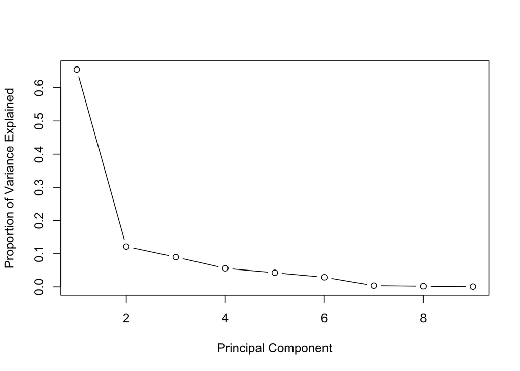

```r
# plotting the scree plot of principal components
plot(PVE, xlab = "Principal Component",
     ylab = "Proportion of Variance Explained",
     type = "b")
```

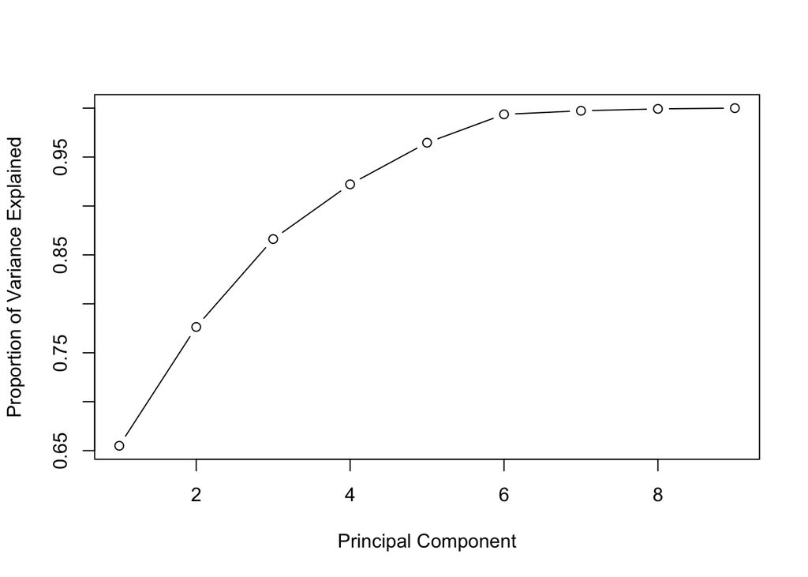

```r
# Plotting the scree plot of cumulative sum of percent variance
plot(cumsum(PVE), xlab = "Principal Component",
     ylab = "Proportion of Variance Explained",
     type = "b")
```

By plotting the scree plot, we can see that we can select first 4 components to reduce the feature dimensions. These 4 components capture around 90% of the variability in the data with a loss of approximately 10%.

```r
# computing principal component vector
evecsCov <- covVector[,1:4]
colnames(evecsCov) <- c("PC1", "PC2", "PC3","PC4")
row.names(evecsCov) <- colnames(pca_data)
evecsCov <- round(evecsCov,3)
evecsCov
```

```
##                                         PC1    PC2    PC3    PC4
## total_cash_compensation              -0.408 -0.036  0.034 -0.051
## base_pay                             -0.377 -0.167 -0.193 -0.387
## overtime                             -0.296  0.296  0.326  0.745
## sick_and_vacation_availed            -0.004 -0.873  0.413  0.195
## other_cash_compensation              -0.308  0.267  0.367 -0.177
## medical_dental_vision                -0.248 -0.186 -0.740  0.435
## retirement_contributions_normal_cost -0.364  0.036  0.038 -0.129
## long_term_disability_life_medicare   -0.398 -0.112  0.028 -0.130
## misc_employment_related_costs        -0.397 -0.029  0.017 -0.023
```

There are 4 principal components in the dataset.  
In principal component 1, we see that total_cash_compensation dominates and the least is for sick_and_vacation_availed. In principal component 2, sick_and_vacation_availed dominates. Third component is dominated by medical_dental_vision. The fourth component is dominated by overtime.

```r
# computing scaled principal components
PC1 <- as.matrix(pca_data) %*% evecsCov[,1]
PC2 <- as.matrix(pca_data) %*% evecsCov[,2]
PC3 <- as.matrix(pca_data) %*% evecsCov[,3]
PC4 <- as.matrix(pca_data) %*% evecsCov[,4]
PC  <- data.frame(PC1,PC2,PC3,PC4)
PC["Department"] <- cleanData["Department"]
head(PC,3)
```

```
##         PC1      PC2      PC3       PC4 Department
## 1 -354478.0 36020.32 61681.14 109740.12       Fire
## 2 -314413.1 25071.35 46714.81  65259.69     Police
## 3 -314665.0 11766.32 32055.69  21458.80     Police
```

In the above code snippet, the scaled principal components are calculated.

# Hypothesis Formulation

### Hypothesis 1:

I have distributed few departments into two groups namely Emergency and Non-emergency as given below based on if the departments are emergency basis and critical or if they are non- emergency and not very important departments. This is purely on my thinking.  
Emergency – Fire and Police  
Non-emergency - Library, Human Resources, Parks/Rec & Neigh Serv P R N S and Public Works

```r
emergency <- subset(myData, myData$Department == "Fire" | myData$Department == "Police")
non_emergency <- subset(myData, myData$Department == "Library" | myData$Department == "Human Resources" | myData$Department == "Parks/Rec & Neigh Serv P R N S" | myData$Department == "Public Works")
```

Emergency and non-emergency groups are grouped as above.

I want to check if variances of salaries in emergency departments is greater than that of non-emergency departments as the salaries have a huge diversity in them.

$\sigma_e^2$: Variance of salaries in Emergency departments  
$\sigma_n^2$: Variance of salaries in Non-emergency departments

##### Test Statistic:

Variance of salaries between Emergency and Non-emergency departments

##### Reference Distribution:

```r
var.test(emergency$total_cash_compensation, non_emergency$total_cash_compensation, alternative = "two.sided")
```

```
##
##  F test to compare two variances
##
## data:  emergency$total_cash_compensation and non_emergency$total_cash_compensation
## F = 3.0788, num df = 2881, denom df = 2783, p-value < 2.2e-16
## alternative hypothesis: true ratio of variances is not equal to 1
## 95 percent confidence interval:
##  2.859992 3.314114
## sample estimates:
## ratio of variances
##           3.078764
```

### Hypothesis 2:

```r
govt <- subset(myData, myData$Department == "City Managers" | myData$Department == "City Councils" | myData$Department == "Environmental Services" | myData$Department == "Retirement Services" | myData$Department == "Office Of Economic Development" | myData$Department == "Community Energy Department" | myData$Department == "Public Works")
non_govt <- subset(myData, myData$Department == "Finance" | myData$Department == "Information Technology" | myData$Department == "Transportation" | myData$Department == "Housing" | myData$Department == "Airport" | myData$Department == "Planning/Building/Code")
```

Government and non-government groups are grouped above.

$\mu_g$: Mean of total cash compensation of employers at government positions  
$\mu_n$: Mean of total cash compensation of employers at non-government positions

H0: $\mu_g$ - $\mu_n$ = 0  
HA: $\mu_g$ - $\mu_n$ > 0

##### Reference Distribution:

Since, I rejected the null hypothesis in Hypothesis 1, I cannot perform pooled t-test for hypothesis in Hypothesis 2.

```r
t.test(govt$total_cash_compensation, non_govt$total_cash_compensation, alternative = "greater", paired = FALSE, var.equal = FALSE, conf.level = 0.95)
```

```
##
##  Welch Two Sample t-test
##
## data:  govt$total_cash_compensation and non_govt$total_cash_compensation
## t = 1.3559, df = 2734.7, p-value = 0.08761
## alternative hypothesis: true difference in means is greater than 0
## 95 percent confidence interval:
##  -529.8752       Inf
## sample estimates:
## mean of x mean of y
##  92649.15  90167.03
```

**The p-value of T-test is 0.08 which is higher than 0.05. We fail to reject the NULL hypothesis. In conclusion, there is no significant difference in the means of total cash compensations at government and non-government positions.**

# Conclusion

It is surprising to see that in the emergency subgroup we see large variance in the total cash compensation than in the non-emergency subgroup. Also, the miscellaneous costs received is only upto $100 for maximum number of people. We also see that the total cash compensation and base pay are highly correlated to each other. Even though it is not mentioned in the dataset, but reimbursements should be a separate column and will be very fascinating to see as to which department gives more reimbursements than the other.

# References

- Exploratory Data Analysis: https://r4ds.had.co.nz/exploratory-data-analysis.html#questions
- Employee Compensation Plan: https://clockify.me/blog/business/compensation-plan/
- R documentation: https://rpubs.com/